# STAT $1210$

Chapter $19$ Homework: Inference about a Population Proportion

Fall $2026$

### Question $1$

A fisheries officer inspects a random sample of $250$ American lobsters landed at ports along the Northumberland Strait. Of these, $38$ show signs of epizootic shell disease.

1. Identify the population, the observational unit and the “success” outcome.
2. Define the population parameter $p$ in words.
3. Calculate the sample proportion $\hat{p}$.
4. Explain the difference between $\hat{p}$ and $p$.
5. If a second random sample of $250$ lobsters were inspected, would you expect the same value of $\hat{p}$? Explain.

**Show solution**

1. The **population** is all American lobsters landed at Northumberland Strait ports (during the inspection period). The **observational unit** is one lobster. A **success** is a lobster showing signs of shell disease. “Success” just means the outcome being counted. It is not a good outcome here.
2. $p$ is the proportion of *all* lobsters landed at these ports that show signs of shell disease.
3. $$\hat{p}=\frac{X}{n}=\frac{38}{250}=\boxed{0.152}$$
   so $15.2\%$ of the sampled lobsters show signs of disease.
4. $\hat{p}=0.152$ is a **statistic**. It is known, calculated from this sample, and would change from sample to sample. $p$ is a **parameter**. It is a fixed but unknown number describing the whole population. We use $\hat{p}$ to estimate $p$.
5. No. A different random sample would almost certainly include different lobsters and give a somewhat different $\hat{p}$. This sample-to-sample variation is described by the sampling distribution of $\hat{p}$, which is what confidence intervals and tests account for.

### Question $2$

Suppose that $30\%$ of all white-tailed deer in a large provincial herd carry a particular parasite, so $p=0.30$. A wildlife agency will test a random sample of $n=200$ deer.

1. What are the mean and standard deviation of the sampling distribution of $\hat{p}$?
2. Check that the sampling distribution is approximately Normal.
3. Find the probability that the sample proportion is greater than $0.35$.
4. Find the probability that the sample proportion is within $0.05$ of the true value $0.30$.
5. How would the standard deviation change if the agency tested $800$ deer instead?

**Show solution**

1. $$\mu_{\hat{p}}=p=\boxed{0.30}\qquad
   \sigma_{\hat{p}}=\sqrt{\frac{(0.30)(0.70)}{200}}=\boxed{0.0324}$$
2. The expected counts are $np=200(0.30)=60$ successes and $n(1-p)=200(0.70)=140$ failures. Both are large, so $\hat{p}$ is approximately Normal. The herd is large, so the $10\%$ condition is also reasonable.
3. $$z=\frac{0.35-0.30}{0.0324}=1.543\qquad
   P(\hat{p}>0.35)=P(Z>1.543)\approx\boxed{0.0614}$$
4. By symmetry, $P(0.25<\hat{p}<0.35)=1-2(0.0614)\approx\boxed{0.8772}$. About $88\%$ of samples of $200$ deer would give a sample proportion within $5$ percentage points of the truth.
5. The standard deviation is proportional to $1/\sqrt{n}$. Multiplying $n$ by $4$ halves it:
   $$\sqrt{\frac{(0.30)(0.70)}{800}}=\boxed{0.0162}$$

```r
sd_phat <- sqrt(0.30 * 0.70 / 200)
pnorm(0.35, mean = 0.30, sd = sd_phat, lower.tail = FALSE)
```

```
## [1] 0.06141132
```

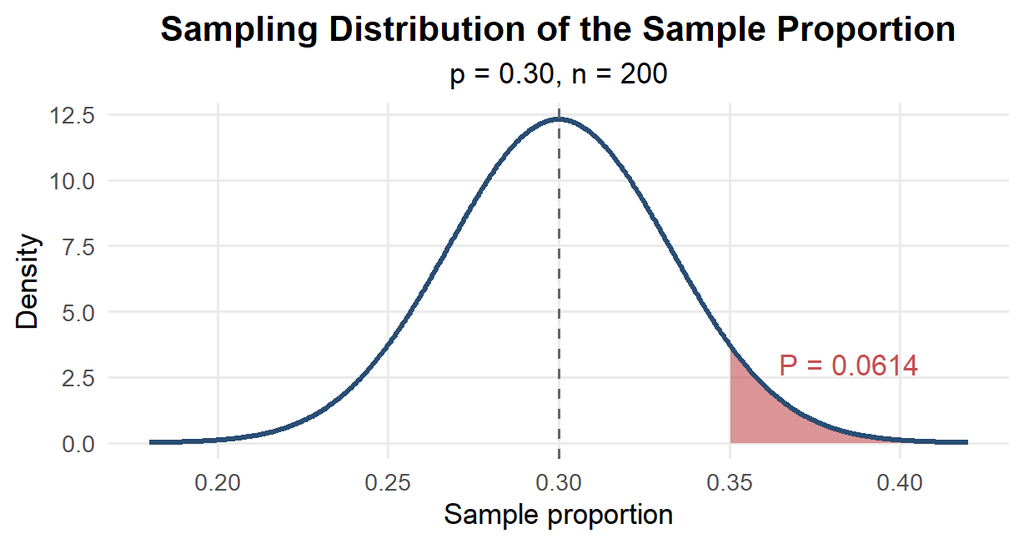

### Question $3$

A random sample of $640$ little brown bats captured at hibernation sites in Nova Scotia found $112$ with visible signs of white-nose syndrome.

1. Check the conditions for a large-sample confidence interval.
2. Construct a $95\%$ confidence interval for the population proportion of bats with visible signs.
3. Interpret the interval in context.
4. Construct a $99\%$ confidence interval.
5. Explain why the $99\%$ interval is wider, and state the trade-off involved.

**Show solution**

1. **Random:** the bats are a random sample. **Independence:** the bat population across hibernation sites is much larger than $10\times640$. **Large counts:** there are $X=112\ge15$ successes and $n-X=528\ge15$ failures. All conditions are met.
2. $$\hat{p}=\frac{112}{640}=0.175$$
   $$SE=\sqrt{\frac{(0.175)(0.825)}{640}}=0.0150$$
   $$m=1.960(0.0150)=0.0294$$
   $$0.175\pm0.0294=\boxed{(0.1456,\ 0.2044)}$$
3. We are $95\%$ confident that between about $14.6\%$ and $20.4\%$ of little brown bats at these hibernation sites show visible signs of white-nose syndrome.
4. With $z^*=2.576$:
   $$m=2.576(0.0150)=0.0387$$
   $$0.175\pm0.0387=\boxed{(0.1363,\ 0.2137)}$$
5. To capture $p$ more often in repeated sampling ($99\%$ instead of $95\%$), the interval needs a larger critical value, so it is wider. The trade-off is between **confidence** and **precision**: more confidence means a less precise estimate, unless the sample size is increased.

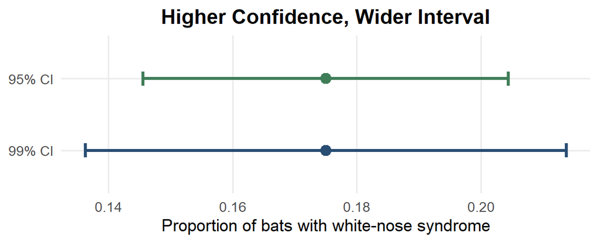

### Question $4$

A news report on the bat survey in Question $3$ makes the statements below. For each one, say whether it is correct and explain why.

1. “There is a $95\%$ probability that the true proportion is between $0.1456$ and $0.2044$.”
2. “If the survey were repeated many times, about $95\%$ of the intervals calculated this way would contain the true proportion.”
3. “The margin of error of $\pm2.9$ percentage points accounts for all sources of error in the survey.”
4. “Because a proportion is being estimated, the interval should use $t^*$ with $639$ degrees of freedom instead of $z^*$.”
5. “About $17.5\%$ of the bats in the sample showed signs of the disease.”

**Show solution**

1. **Incorrect.** Once the interval is calculated, it either contains the fixed value $p$ or it does not. The $95\%$ describes the long-run success rate of the *method*, not the probability for one calculated interval.
2. **Correct.** This is exactly what $95\%$ confidence means (assuming the conditions hold).
3. **Incorrect.** The margin of error covers only *random sampling* variation. It does not cover bias, for example if sick bats are easier or harder to capture, or errors in identifying visible signs of the disease.
4. **Incorrect.** For a mean, $t$ is used because a *separate* parameter $\sigma$ must be estimated by $s$. For a proportion, the spread $p(1-p)/n$ depends only on $p$ itself, so the procedure uses the Normal approximation and $z^*$.
5. **Correct.** This describes the sample: $\hat{p}=112/640=0.175$. No inference is needed for a statement about the sample itself.

### Question $5$

Historically, $70\%$ of piping plover eggs on a protected PEI beach hatch successfully. After a season with unusually high storm activity, biologists monitor a random sample of $150$ eggs and find that $93$ hatch. They want to know whether the hatching rate has dropped.

1. State the hypotheses.
2. Check the conditions for the one-proportion $z$ test.
3. Calculate the test statistic.
4. Calculate the $P$-value.
5. State a conclusion at $\alpha=0.05$. Can the biologists conclude that the storms *caused* the change?

**Show solution**

1. Let $p$ be the proportion of eggs that hatch this season.
   $$H_0:p=0.70\qquad
   H_a:p<0.70$$
   The alternative is lower-tailed because the question asks whether the rate has *dropped*.
2. The eggs are a random sample, and the expected counts **under $H_0$** are $np_0=150(0.70)=105\ge10$ and $n(1-p_0)=150(0.30)=45\ge10$. The conditions are met. Eggs in the same nest may not be fully independent, which is a limitation worth noting.
3. $$\hat{p}=\frac{93}{150}=0.62$$
   $$SE_0=\sqrt{\frac{(0.70)(0.30)}{150}}=0.0374$$
   $$z=\frac{0.62-0.70}{0.0374}=\boxed{-2.138}$$
   Note that the standard error uses $p_0=0.70$, not $\hat{p}$.
4. $$P=P(Z\le-2.138)\approx\boxed{0.0163}$$
5. Because $0.0163<0.05$, reject $H_0$. There is significant evidence that the hatching rate this season is below the historical $70\%$.  
   The biologists **cannot** conclude that the storms caused the drop. This is an observational comparison with a historical rate, and other factors that changed this season, such as predators, temperature or human disturbance, could also be responsible.

```r
p_hat <- 93 / 150
z <- (p_hat - 0.70) / sqrt(0.70 * 0.30 / 150)
c(z = z, p_value = pnorm(z))
```

```
##           z     p_value
## -2.13808994  0.01625472
```

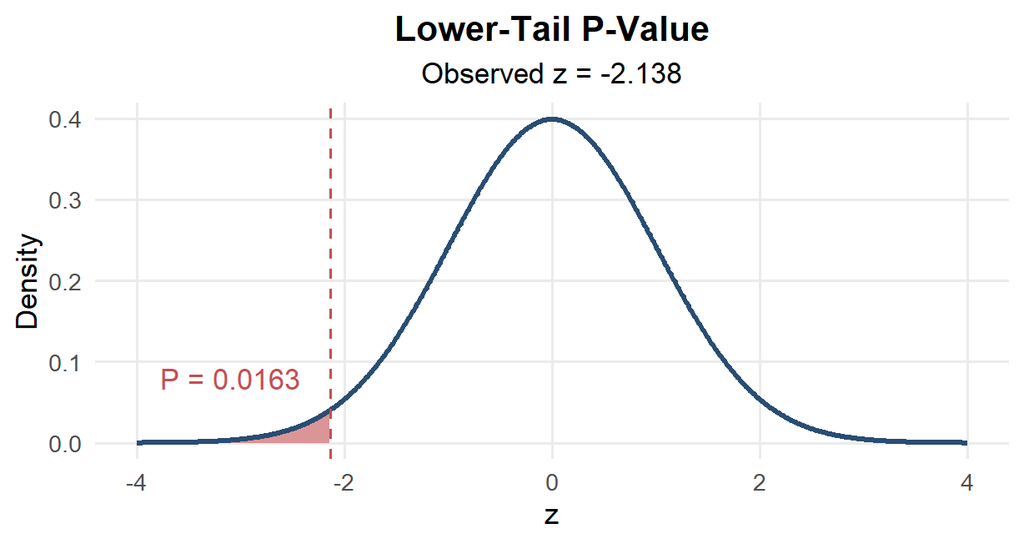

### Question $6$

Are toads “right-pawed”? A researcher observes a random sample of $60$ cane toads removing a strip of paper from their snouts. $36$ use their right forelimb. If toads have no preference, the proportion using the right forelimb would be $0.5$.

1. State hypotheses to test whether toads have a preference for either side.
2. Calculate the test statistic and the two-sided $P$-value.
3. State a conclusion at $\alpha=0.05$.
4. Construct a $95\%$ large-sample confidence interval for $p$. Is it consistent with the test?
5. A classmate says, “The test didn’t reject, so toads have no paw preference.” Explain what is wrong with this statement.

**Show solution**

1. Let $p$ be the proportion of cane toads that use the right forelimb.
   $$H_0:p=0.5\qquad H_a:p\neq0.5$$
   The alternative is two-sided because a preference in *either* direction counts.
2. The expected counts are $60(0.5)=30\ge10$ for each side, so the conditions are met.
   $$\hat{p}=\frac{36}{60}=0.60$$
   $$SE_0=\sqrt{\frac{(0.5)(0.5)}{60}}=0.0645$$
   $$z=\frac{0.60-0.50}{0.0645}=\boxed{1.549}$$
   $$P=2P(Z\ge1.549)\approx\boxed{0.1213}$$
3. Because $0.1213>0.05$, fail to reject $H_0$. The data do not give significant evidence of a forelimb preference.
4. The observed counts are $36\ge15$ and $24\ge15$.
   $$SE=\sqrt{\frac{(0.60)(0.40)}{60}}=0.0632$$
   $$0.60\pm1.960(0.0632)=\boxed{(0.476,\
   0.724)}$$
   The interval contains $0.5$, which is consistent with failing to reject. (The interval and test use slightly different standard errors, based on $\hat{p}$ and $p_0$ respectively, so they can occasionally disagree when a result is near the cutoff.)
5. Failing to reject $H_0$ does not prove $H_0$. The interval shows that values from about $0.48$ up to $0.72$ are all plausible, so a fairly strong right-paw preference has not been ruled out. With only $60$ toads, the study may simply lack the precision to detect a moderate preference. The correct statement is: “The data do not provide convincing evidence of a preference.”

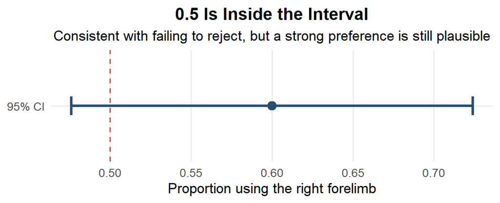

### Question $7$

A veterinary student tests whether more than $30\%$ of dairy cows in a region have subclinical mastitis. In a random sample of $120$ cows, $45$ test positive. The student’s work is shown below.

$H_0:\hat{p}=0.30\qquad H_a:\hat{p}>0.30$  
$\hat{p}=45/120=0.375$  
$SE=\sqrt{0.375(0.625)/120}=0.0442$  
$z=(0.375-0.30)/0.0442=1.697$, so $P=0.0449$  
“Since $P<0.05$, we have proved that more than $30\%$ of cows have subclinical mastitis.”

1. Identify the error in the hypotheses and correct it.
2. Identify the error in the standard error and recompute it correctly.
3. Recompute the test statistic and $P$-value.
4. Identify the error in the conclusion and rewrite it correctly.
5. The student also wants a $95\%$ confidence interval and plans to use $SE=\sqrt{0.30(0.70)/120}$. Is that correct? Explain.

**Show solution**

1. Hypotheses are always about the **parameter** $p$, never the statistic $\hat{p}$. We already know $\hat{p}=0.375$, so there is nothing to test about it.
   $$H_0:p=0.30\qquad
   H_a:p>0.30$$
2. A test calculates everything assuming $H_0$ is true, so the standard error must use $p_0=0.30$, not $\hat{p}$:
   $$SE_0=\sqrt{\frac{(0.30)(0.70)}{120}}=\boxed{0.0418}$$
3. $$z=\frac{0.375-0.30}{0.0418}=\boxed{1.793}$$
   $$P=P(Z\ge1.793)\approx\boxed{0.0365}$$
   The expected counts $120(0.30)=36$ and $120(0.70)=84$ are both at least $10$, so the test is valid.
4. A test never “proves” anything, and a $P$-value just below $0.05$ is moderate evidence, not certainty. A correct conclusion: “Because $P=0.0365<0.05$, we reject $H_0$. There is significant evidence that more than $30\%$ of dairy cows in the region have subclinical mastitis.”
5. No. A confidence interval has **no null value**, so it uses the observed $\hat{p}$:
   $$SE=\sqrt{\frac{(0.375)(0.625)}{120}}=0.0442$$
   The rule is: **test uses $p_0$; interval uses $\hat{p}$**. The student mixed the two up in both directions.

### Question $8$

Public health researchers drag cloths along trails in a random sample of Nova Scotia parks and collect $300$ blacklegged ticks. Laboratory testing finds that $66$ carry *Borrelia burgdorferi*, the bacterium that causes Lyme disease. A report from five years ago estimated that $18\%$ of ticks in the province were infected.

1. **State and plan.** Define $p$, and state hypotheses to test whether the infection rate has changed from $18\%$.
2. **Solve: test.** Check the conditions, then calculate the test statistic and two-sided $P$-value. State the conclusion at $\alpha=0.05$.
3. **Solve: interval.** Construct a $95\%$ confidence interval for $p$ and interpret it. Is it consistent with the test?
4. **Compare.** The test in part 2 and the interval in part 3 use different standard errors. State both values and explain why they differ.
5. **Scope.** Ticks were only collected along accessible trails. Explain how this could affect the conclusions, and whether a larger sample would fix the problem.

**Show solution**

1. Let $p$ be the proportion of blacklegged ticks in Nova Scotia parks that carry *B. burgdorferi*.
   $$H_0:p=0.18\qquad H_a:p\neq0.18$$
   The alternative is two-sided because the question asks whether the rate has *changed*, in either direction.
2. **Conditions:** the parks were randomly sampled, the tick population is far larger than $3000$, and the expected counts under $H_0$ are $300(0.18)=54\ge10$ and $300(0.82)=246\ge10$.
   $$\hat{p}=\frac{66}{300}=0.22$$
   $$SE_0=\sqrt{\frac{(0.18)(0.82)}{300}}=0.0222$$
   $$z=\frac{0.22-0.18}{0.0222}=\boxed{1.803}$$
   $$P=2P(Z\ge1.803)\approx\boxed{0.0713}$$
   Because $0.0713>0.05$, fail to reject $H_0$. The data do not give significant evidence at the $5\%$ level that the infection rate has changed from $18\%$, although the sample rate of $22\%$ is suggestive.
3. The observed counts are $66\ge15$ and $234\ge15$.
   $$SE=\sqrt{\frac{(0.22)(0.78)}{300}}=0.0239$$
   $$m=1.960(0.0239)=0.0469$$
   $$0.22\pm0.0469=\boxed{(0.173,\ 0.267)}$$
   We are $95\%$ confident that between about $17.3\%$ and $26.7\%$ of ticks in these parks are infected. The interval contains $0.18$, which is consistent with failing to reject. It also shows that rates as high as about $27\%$ are plausible, so a meaningful increase has not been ruled out.
4. The test uses $SE_0=0.0222$, and the interval uses $SE=0.0239$. A test assumes $H_0$ is true, so its standard error is calculated under the null value $p_0=0.18$. A confidence interval has no null value, so it can only use the observed $\hat{p}=0.22$. The same reasoning explains why the test’s conditions use expected counts ($np_0$, $n(1-p_0)$) while the interval’s conditions use observed counts ($X$, $n-X$).
5. Ticks along accessible trails may not represent ticks in the wider park, for example in dense forest or leaf litter away from trails. Trail-side habitat may also be visited by different host animals, which could make infection rates higher or lower there. This is **selection bias**. The results apply most directly to ticks along trails, which is still relevant for hikers. A larger sample would shrink the margin of error, but it would **not** fix the bias. It would just give a more precise estimate of the wrong population. Fixing the problem requires changing *how* ticks are sampled, not *how many*.

```r
x <- 66; n <- 300; p0 <- 0.18
p_hat <- x / n

# Test (standard error uses p0)
se_null <- sqrt(p0 * (1 - p0) / n)
z <- (p_hat - p0) / se_null
c(se_null = se_null, z = z, p_value = 2 * pnorm(-abs(z)))
```

```
##    se_null          z    p_value
## 0.02218107 1.80333927 0.07133495
```

```r
# Interval (standard error uses p_hat)
se_ci <- sqrt(p_hat * (1 - p_hat) / n)
c(se_ci = se_ci, p_hat + c(-1, 1) * qnorm(0.975) * se_ci)
```

```
##      se_ci
## 0.02391652 0.17312448 0.26687552
```

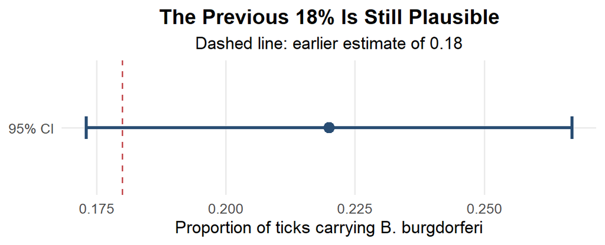